# Project 5

Austin Sarney

## Introduction

I decided to focus on releases related to the Energy Portfolio from the current National-ACT-NZ First government. I decided to focus on this because the Energy Portfolio is quite relevant at the moment due to the petrol shortage, and the current government is the most interesting data to me because it is still changing over time.

When using data from the beehive website, I will need to accurately reproduce the material and acknowledge the source of the content. This doesn’t include any photos from the website. (Source: https://www.beehive.govt.nz/copyright)

From the [robots.txt file](https://www.beehive.govt.nz/robots.txt), (assuming they intentionally used that “/”), I am allowed to automatically scrape their /search urls.

## Visualisation

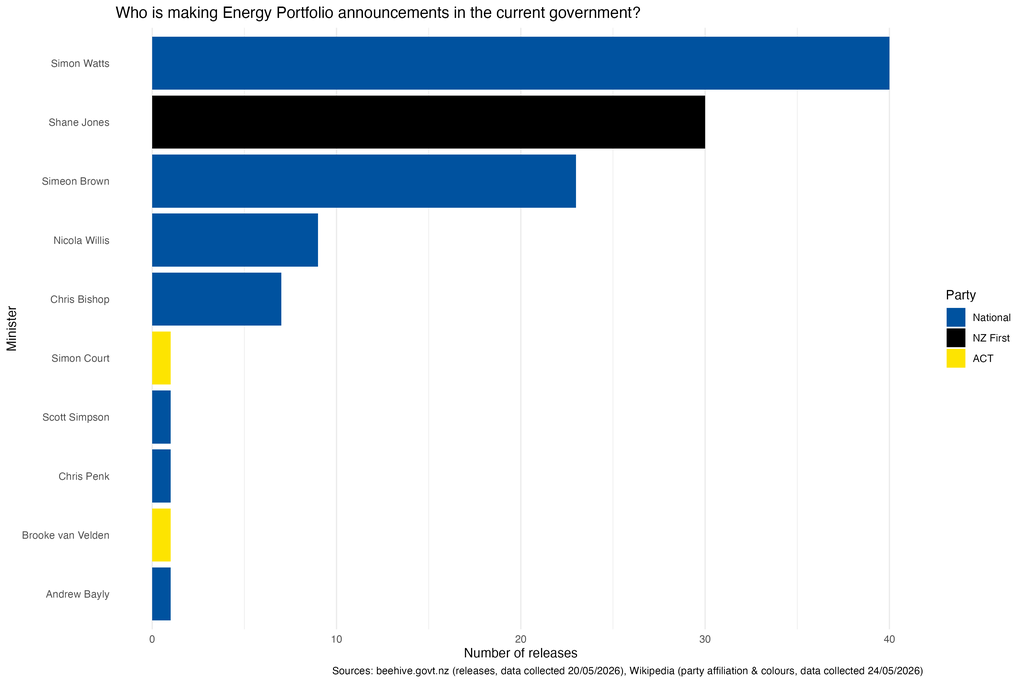

The main purpose of my visualisation is to show who has been making announcements in the Energy Portfolio in the current government. It also shows which political party each minister belongs to, highlighting that National has significantly more releases than the other 2 parties who have had ministers make announcements.

## Creativity

A creative thing in my project is the way that I scraped the party colours from the Wikipedia page for List of Political Parties in New Zealand. I first tried using the Wikipedia API but it didn’t give me the colour hex values. According to the robots.txt file, slow robots are allowed to scrape Wikipedia articles. My script makes only 1 request, so it is allowed. This means that if the political parties ever change their colours, my code will automatically get the new colours from Wikipedia.

## Learning reflection

An important thing from module 5 is that it is still possible to automatically extract data from websites even if there isn’t a convenient API that gives all the data to you cleanly. In this project we could still extract data quickly by using a web browser to download the HTML to bypass the beehive bot blockers. If I were to manually copy and paste each line of the page into a spreadsheet, it would have taken me much longer than it did to use rvest.

I am interested in exploring how data can be collected by repeatedly scraping things that change over time, such as the trending pages of social media websites. I think this data will be interesting to scrape automatically because it will be able to collect its own data so it can change over time without needing anyone to give it new data.

## Self review

**Understanding R’s error messages**

While doing the projects for this course, because they were very open ended I had the opportunity to encounter many different error messages. Here’s an actual one from this project: “Error in `method(update_ggplot, list(class_any, ggplot2::ggplot))`:! Can’t add `ministers_with_parties %>% ggplot()` to a object.” While I still think the messages aren’t super descriptive of the problem, I was still able to tell that there was a problem with a “+” somewhere in the code, and then I saw that I had a trailing “+” on the final part of the ggplot where there shouldn’t be one. By seeing so many error messages I learned how to interpret their vague wording better.

**Manipulating data with `mutate()`**

Ever since module 3 introduced it, this function has been very useful for almost every section of the remaining projects. Being able to create new variables that weren’t present in the original data is extremely useful. In this project I found it useful to create cleaned versions of the party names, and other new variables.

## Appendix

```r
scrape_search_results <- function(page_path) {
  # Read HTML
  html_doc <- read_html(page_path)

  # Extract the isolated search result nodes (the individual cards)
  # This will depend on how you've acquired the results
  # Look for .search-result or .teaser (though there may be others)
  nodes <- html_doc %>% html_elements(".search-result")

  # Map over each individual search result
  map_df(nodes, function(node) {
    # Title
    title_element <- node %>% html_element(".views-field-title")
    title <- title_element %>% html_text2()

    # Date and time
    date_element <- node %>% html_element("time")
    datetime  <- date_element %>% html_attr("datetime") # Raw timestamp
    date_text <- date_element %>% html_text2()          # Human-readable text

    # Summary
    summary <- node %>% html_element(".field-content") %>% html_text2()

    # Ministers
    minister <- node %>%
      html_elements(".minister__title") %>%
      html_text2() %>%
      # trim out excess white space noise, and collapse them using a semicolon
      str_trim() %>%
      paste(collapse = ";")

    # Portfolios
    portfolio <- node %>%
      html_elements(".taxonomy-term--type-portfolios") %>%
      html_text2() %>%
      # trim out excess white space noise, and collapse them using a semicolon
      str_trim() %>%
      paste(collapse = ";")

    # Combine individual results into a tidy tibble
    tibble(
      datetime   = datetime,
      date_text  = date_text,
      title      = title,
      ministers  = minister,
      portfolios = portfolio,
      summary    = summary
    )
  })
}
```

```r
library(tidyverse) #✨
library(jsonlite)
library(rvest)

source("scrape_html.R") #Load the function

beehive <- map_df(1:4, ~ scrape_search_results(paste0("html/page", ., ".html")))

saveRDS(beehive, "beehive") #Save the beehive website data

#Extract data to search wikipedia
minister_names <- beehive %>%
  separate_rows(ministers, sep = ";") %>%
  pull(ministers) %>%
  str_remove("Hon ") %>%
  unique()


source("get_wikipedia_infobox.R")

ministers <- map_df(minister_names, ~ get_wikipedia_infobox(.)) #search wikipedia

saveRDS(ministers, "ministers") #save the wikipedia data for later
```

```r
library(tidyverse)
library(rvest)

beehive <- readRDS("beehive")
ministers <- readRDS("ministers")

beehive <- beehive %>%
  mutate(minister_clean = str_remove_all(ministers, "Hon |Rt "))

minister_parties <- ministers %>%
  filter(label == "Party")

ministers_with_parties <- beehive %>%
  separate_rows(minister_clean, sep=";") %>%
  group_by(minister_clean) %>%
  summarise(n()) %>%
  left_join(minister_parties, by=c("minister_clean"="minister"))

ministers_with_parties <- ministers_with_parties %>%
  rename(name=1, releases=2, party_from_wikipedia=6) %>%
  select(name, releases, party_from_wikipedia) %>%
  mutate(party_clean = case_when(
    str_detect(party_from_wikipedia, "National") ~ "National", #Scott Simpson's page says "National Party" instead of "National" like all the others
    str_detect(party_from_wikipedia, "Labour") ~ "Labour",
    str_detect(party_from_wikipedia, "Green") ~ "Green",
    str_detect(party_from_wikipedia, "ACT") ~ "ACT",
    str_detect(party_from_wikipedia, "NZ First") ~ "NZ First", #Shane Jones' party affiliation on Wikipedia is listed with the date included, so this cleaning step is necessary
    str_detect(party_from_wikipedia, "Maori|Māori") ~ "Māori",
    TRUE ~ "Unknown Party"

  ),
  ) %>%
  group_by(party_clean) %>%
  mutate(party_max_num_releases = max(releases)) %>% #So that I can make the legend show in a more natural order
  ungroup()




wikipedia_parties_page <- read_html("https://en.wikipedia.org/wiki/List_of_political_parties_in_New_Zealand")

wikipedia_table <- wikipedia_parties_page %>% html_element(".wikitable")

header_done <- FALSE
party_data <- tibble()
for (row in wikipedia_table %>% html_elements("tr")) { #woah its a for loop before module 6
  if (!header_done) {#The header row doesn't have any data in it
  header_done <- TRUE
  next #skip the rest of this iteration
  }


  party_colour <- row %>%
    html_element("td") %>%
    html_attr("style") %>%
    substr(18, 24)

  party_name <- row %>% #I promise chatgpt didn't write this
    html_elements("td:nth-child(2)") %>% #there was a weird error message where R didn't want to let me index into the list. So here I used a fancy html selector instead
    html_text2()

  party_data <- bind_rows(party_data, tibble(party_colour=c(party_colour), party_name=c(party_name)))
}

party_data <- party_data %>% #Same as before, but now its because most of them have the word "Party" after them
mutate(party_clean = case_when(
  str_detect(party_name, "National") ~ "National",
  str_detect(party_name, "Labour") ~ "Labour",
  str_detect(party_name, "Green") ~ "Green",
  str_detect(party_name, "ACT") ~ "ACT",
  str_detect(party_name, "First") ~ "NZ First",
  str_detect(party_name, "Maori|Māori") ~ "Māori",
  TRUE ~ "Unknown Party"
))

ministers_with_parties <- ministers_with_parties %>%
  left_join(party_data, by=c("party_clean"="party_clean"))

party_data <- party_data %>%
  inner_join(
    ministers_with_parties %>% distinct(party_clean, .keep_all=TRUE),
    by = "party_clean"
  ) %>%
  select("party_clean", "party_colour.x", "party_max_num_releases")


party_data <- party_data %>%
  arrange(desc(party_max_num_releases)) #Make it so the legend shows up in the sorted order



ministers_with_parties %>%
  ggplot() +
  geom_col(aes(y=reorder(name, +releases), x=releases, fill=party_colour)) +
  theme_minimal() +
  labs(
    title = "Who is making Energy Portfolio announcements in the current government?",
    x = "Number of releases",
    y = "Minister",
    caption = "Sources: beehive.govt.nz (releases, data collected 20/05/2026), Wikipedia (party affiliation & colours, data collected 24/05/2026) ",
    fill = "Party"
  ) +
  theme(
    panel.grid.major.y = element_blank()
  ) +
  scale_fill_identity(
    guide = "legend", #by default there is no guide
    labels = party_data$party_clean, #These 2 lines match up the party name to colours
    breaks = party_data$party_colour.x #so that the legend is correct
  )

ggsave("my_viz.png", units = "in", width = 12, height = 8)
```